# Safe Flexible Hypothesis Tests for Practical Scenarios

Rosanne Turner and Alexander Ly

*Safe tests* is a collective name for a new form of hypothesis tests that yield *s-values* (instead of *p-values*). The original paper on s-values by Grünwald, de Heide and Koolen can be found [here](https://arxiv.org/abs/1906.07801). For each hypothesis testing setting where one would normally use a $p$-value, a safe test can be designed, with a number of advantages that are elaborately described and illustrated in this vignette. Currently, this package provide s-values for the t-test, Fisher’s exact test, and the chi-squared test (the safe test of 2 proportions). These safe tests were designed to be *GROW*; they perform the best under the worst case in the alternative hypothesis (see the [original paper](https://arxiv.org/abs/1906.07801)).

> Technically, S-values are non-negative random variables (test statistics) that have an expected value of at most one under the null hypothesis. The S-value can be interpreted as an gamble against the null hypothesis in which an investment of 1$ returns $S$$ whenever the null hypothesis fails to hold true. Hence, the larger the observed $S$-value, the larger the incentive to reject the null.

A big advantage of the s-values over their $p$-value equivalents is that safe tests conserve the type I error guarantee (false positive rate) *regardless of the sample size*. This implies that the evidence can be monitored as the observations come in, and the researcher is allowed to stop the experiment early (optional stopping), whenever the evidence is compelling. By stopping early fewer participants will be put at risk. In particular, those patients who are assigned to the control condition, when a treatment is effective. Safe tests also allow for optional continuation, which means that the researcher can extend the experiment irrespectively of the motivation. For instance, if more funds become available, or if the evidence looks promising and the funding agency, a reviewer, or an editor urges the experimenter to collect more data.

Importantly, for the safe tests presented here neither optional stopping nor continuation leads to the test exceeding the promised type I error guarantee. As the results do not depend on the planned, current, or future sample sizes, safe tests allow for *anytime valid* inferences. We illustrate these properties below.

Firstly, we show how to design an experiment based on safe tests.

- for testing means
- for testing proportions

Secondly, simulations are run to show that safe tests indeed conserve the type I error guarantee under optional stopping. We also show that optional stopping causes the false null rejection rate of the classical $p$-value test to exceed the promised level $\alpha$ type I error guarantee. This implies that with classical tests one cannot adapt to the information acquired during the study without increasing the risk of making a false discovery.

- for testing means
- for testing proportions

Lastly, it is shown that *optionally continuing non-significant experiments* also causes the $p$-value tests to exceed the promised level $\alpha$ type I error guarantee, whereas this is not the case for safe tests.

- for testing means
- for testing proportions

This demonstration further emphasises the rigidity of experimental designs when inference is based on a classical test: the experiment cannot be stopped early, or extended. Thus, the planned sample size has to be final. As such, the protocol needs to account for possible future sample sizes, which is practically impossible to plan for. Even if such a protocol can be made, there is no guarantee that the experiments go exactly according to plan, as things might go wrong during the study.

The ability to act on information that accumulates during the study – without sacrificing the correctness of the resulting inference – was the main motivation for the development of safe tests, as it provides experimenters with the much needed flexibility.

## Installation

The stable version can be installed by entering in `R`:

```r
install.packages("safestats")
```

The development version can be found on [GitHub](https://github.com/alexanderlynl/safestats), which can be installed with the `devtools` package from [CRAN](https://cran.r-project.org/package=devtools) by entering in `R`:

```r
devtools::install_github("AlexanderLyNL/safestats", build_vignettes = TRUE)
```

The command

```r
library(safestats)
```

loads the package.

# Test of Means: T-Tests

## 1. Designing Safe Experiments

### Type I error and type II errors

To avoid bringing an ineffective medicine to the market, experiments need to be conducted in which the null hypothesis of no effect is tested. Here we show how flexible experiments based on safe tests can be designed.

As the problem is statistical in nature, due to variability between patients, we cannot guarantee that 0% of the medicine that pass the test will be ineffective. Instead, the target is to bound the type I error rate by a tolerable $\alpha$, say, $\alpha = 0.05$. In other words, at most 5 out of the 100 drugs that pass the safe test are allowed to be ineffective.

At the same time, we would like to avoid a type II error, that is, missing out on finding an effect, while there is one. Typically, the targetted type II error rate is $\beta = 0.20$, which implies that whenever there truly is an effect, an experiment needs to be designed in such a way that with $1 - \beta =$ 80% chance the effect is detected.

### Case (I): Designing experiments with the minimal clinically relevant effect size known

Not all effects are equally important, especially, when a minimal clinically relevant effect size can be formulated. For instance, suppose that a population of interest has a population average systolic blood pressure of $\mu = 120$ mmHg and that the population standard deviation is $\sigma = 15$. Suppose further that all approved blood pressure drugs change the blood pressure by at least 9 mmHg, then a minimal clinically relevant effect size can be defined as $\delta_{\min} = (\mu_{\text{post}} - \mu_{\text{pre}}) / (\sqrt{2} \sigma) = 9 / (15 \sqrt{2} ) = 0.42$, where $\mu_{\text{post}}$ represents the average blood pressure after treatment and $\mu_{\text{pre}}$ the average blood pressure before treatment of the population of interest. The $\sqrt{2}$-term in the denominator is a result of the measurements being paired.

Based on a tolerable type I error rate of $\alpha = 0.05$, type II error rate of $\beta = 0.20$, and minimal clinical effect size of $\delta_{\min} \approx 0.42$, the following code shows that we then need to plan an experiment consisting of 63 patients each measured before (n2Plan) and after (n1Plan) the treatment.

```r
alpha <- 0.05
beta <- 0.2
deltaMin <- 9/(sqrt(2)*15)

designObj <- designSafeT(deltaMin=deltaMin, alpha=alpha, beta=beta,
                         alternative="greater", testType="pairedSampleT")
designObj
```

```
#>
#>         Safe Paired Sample T-Test
#>
#> Requires an experiment with sample sizes:
#>     n1Plan = 63 and n2Plan = 63
#> to find an effect size of at least:
#>     deltaMin = 0.42426
#>
#> with:
#>     power = 0.8 (thus, beta = 0.2)
#> under the alternative:
#>     true difference in means ('x' minus 'y') is greater than 0
#>
#> Based on the decision rule S > 1/alpha:
#>     S > 20
#> which occurs with chance less than:
#>     alpha = 0.05
#> under iid normally distributed data and the null hypothesis:
#>     mu = 0
```

### Case (II): Minimal clinically relevant effect size unknown, but maximum number of samples known.

It is not always clear what the minimal clinically relevant effect size is. In that case, the design function can be called for a reasonable range of minimal clinically relevant effect sizes, when it is provided with the tolerable type I and type II error rates. Furthermore, when it is a priori known that only, say, 100 samples can be collected due to budget constraints, then the following function allows for a futility analysis:

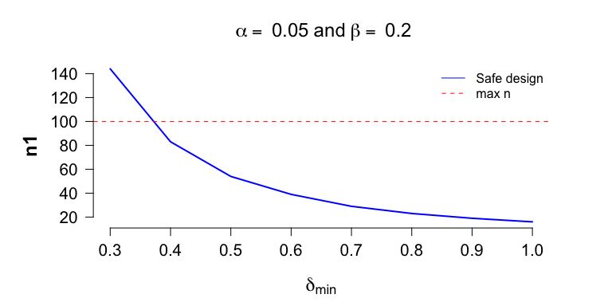

```r
# Recall:
# alpha <- 0.05
# beta <- 0.2

result <- plotSafeTDesignSampleSizeProfile(alpha=alpha, beta=beta,
                                           maxN=100,
                                           testType="pairedSampleT")
```

The plot shows that when we have budget for at most 100 paired samples, we can only guarantee a power of 80%, if the true effect size is at least 0.37. If a field expert believes that an effect size of 0.3 is realistic, then the plot shows that we should either apply for additional grant money to test an additional 44 patients, or decide that it’s futile to set up this experiment, and spend our time and efforts on a different endeavour.

## 2. Inference with Safe Tests: Full experiment

Firstly, we show that inference based on safe tests conserve the tolerable $\alpha$-level, if the null hypothesis of no effect is rejected whenever the s-value, the outcome of a safe test, is larger than $1/\alpha$. For instance, for $\alpha = 0.05$ the safe test rejects the null whenever the s-value is than 20. The level $\alpha$ type I error rate is also guaranteed under (early) optional stopping. Secondly, we show that there is a high chance of stopping early whenever the true effect size is at least as large as the minimal clinically relevant effect size.

### Safe tests conserve the type I error rate: Full experiment

To see that safe tests only lead to a false null rejection very infrequently, we consider an experiment with the same number of samples as it was planned for, but with no effect, that is,

```r
set.seed(1)
preData <- rnorm(n=designObj$n1Plan, mean=120, sd=15)
postData <- rnorm(n=designObj$n2Plan, mean=120, sd=15)
# Thus, the true delta is 0:
# deltaTrue <- (120-120)/(sqrt(2)*15)
```

The safe test applied to data under the null results in an s-value that is larger than $1/\alpha = 20$ with at most $\alpha =$ 5% chance. In particular,

```r
safeTTest(x=preData, y=postData, alternative = "greater",
          designObj=designObj, paired=TRUE)
```

```
#>
#>         Safe Paired Sample T-Test
#>
#> Data: preData and postData
#> sample estimates:
#> mean of the differences
#>                 1.14226
#>
#> Test summary: t = 0.48905, df = 62.
#> The test designed with alpha = 0.05
#> s-value = 0.21959 > 1/alpha = 20 : FALSE
#>
#> Experiments required n1Plan = 63 and n2Plan = 63 samples.
#> to guarantee a power = 0.8 (beta =0.2).
#> under the alternative hypothesis:
#> true difference in means ('x' minus 'y') is greater than 0
#> and deltaMin = 0.4242641
```

or equivalently with syntax closely resembling the standard t.test code in R:

```r
safe.t.test(x=preData, y=postData, alternative = "greater",
            designObj=designObj, paired=TRUE)
```

```
#>
#>         Safe Paired Sample T-Test
#>
#> Data: preData and postData
#> sample estimates:
#> mean of the differences
#>                 1.14226
#>
#> Test summary: t = 0.48905, df = 62.
#> The test designed with alpha = 0.05
#> s-value = 0.21959 > 1/alpha = 20 : FALSE
#>
#> Experiments required n1Plan = 63 and n2Plan = 63 samples.
#> to guarantee a power = 0.8 (beta =0.2).
#> under the alternative hypothesis:
#> true difference in means ('x' minus 'y') is greater than 0
#> and deltaMin = 0.4242641
```

The following code replicates this setting a 1,000 times and shows that indeed, only a very few times will the s-values cross the boundary of $1/\alpha$ under the null:

```r
# alpha <- 0.05

set.seed(1)
sValues <- replicate(n=1000, expr={
  preData <- rnorm(n=designObj[["n1Plan"]], mean=120, sd=15)
  postData <- rnorm(n=designObj[["n2Plan"]], mean=120, sd=15)
  safeTTest(x=preData, y=postData, alternative = "greater",
            designObj=designObj,paired=TRUE)$sValue}
)

mean(sValues > 20)
```

```
#> [1] 0.008
```

```r
mean(sValues > 20) < alpha
```

```
#> [1] TRUE
```

### The designed safe tests is as powerful as planned: Full experiment

If the true effect size equals the minimal clinical effect size and the experiment is run as planned, then the safe tests detects the effect with $1 - \beta =$ 80% chance as promised. This is shown by the following code for one experiment

```r
set.seed(1)
preData <- rnorm(n=designObj[["n1Plan"]], mean=120, sd=15)
postData <- rnorm(n=designObj[["n2Plan"]], mean=111, sd=15)

safeTTest(x=preData, y=postData, alternative = "greater",
          designObj=designObj, paired=TRUE)
```

```
#>
#>         Safe Paired Sample T-Test
#>
#> Data: preData and postData
#> sample estimates:
#> mean of the differences
#>                10.14226
#>
#> Test summary: t = 4.34239, df = 62.
#> The test designed with alpha = 0.05
#> s-value = 635.0411 > 1/alpha = 20 : TRUE
#>
#> Experiments required n1Plan = 63 and n2Plan = 63 samples.
#> to guarantee a power = 0.8 (beta =0.2).
#> under the alternative hypothesis:
#> true difference in means ('x' minus 'y') is greater than 0
#> and deltaMin = 0.4242641
```

and by the following code for multiple experiments

```r
# Recall:
# alpha <- 0.05
# beta <- 0.2
power <- 1-beta

set.seed(1)
sValues <- replicate(n=1000, expr={
  preData <- rnorm(n=designObj[["n1Plan"]], mean=120, sd=15)
  postData <- rnorm(n=designObj[["n2Plan"]], mean=111, sd=15)
  safeTTest(x=preData, y=postData, alternative = "greater", designObj=designObj,
            paired=TRUE)$sValue})
mean(sValues > 1/alpha)
```

```
#> [1] 0.808
```

```r
mean(sValues > 1/alpha) >= power
```

```
#> [1] TRUE
```

Due to sampling error, the average number of times that $S > 1 / \alpha$ might not always be larger than the specified power, but it should always be close to it. The sampling error decreases as the number of replications increases and converges to 80%.

## Safe Tests Allow for Optional Stopping without Inflating the Type I Error Rate above the Tolerable $\alpha$-Level

What makes the safe tests in this package particularly interesting is that they allow for early stopping without the test exceeding the tolerable type I error rate of $\alpha$. This means that the evidence can be monitored as the data comes in, and when there is a sufficient amount of evidence against the null, thus, $S > 1/\alpha$, the experiment can be stopped early, which therefore increases efficiency.

> Note that not all s-values necessarily allow for optional stopping: this only holds for some special s-values, that are also *test martingales*. More information can be found, for example, in the first author’s [master thesis](https://www.universiteitleiden.nl/binaries/content/assets/science/mi/scripties/statscience/2019-2020/thesis_rjturner_for_publication.pdf), Chapter 5.

For this purpose, we use the design that was derived above, that is,

```r
designObj
```

```
#>
#>         Safe Paired Sample T-Test
#>
#> Requires an experiment with sample sizes:
#>     n1Plan = 63 and n2Plan = 63
#> to find an effect size of at least:
#>     deltaMin = 0.42426
#>
#> with:
#>     power = 0.8 (thus, beta = 0.2)
#> under the alternative:
#>     true difference in means ('x' minus 'y') is greater than 0
#>
#> Based on the decision rule S > 1/alpha:
#>     S > 20
#> which occurs with chance less than:
#>     alpha = 0.05
#> under iid normally distributed data and the null hypothesis:
#>     mu = 0
```

### Safe tests detect the effect early if it is present: deltaTrue equal to deltaMin

The following code replicates 1,000 experiments and each data set is generated with a true effect size that equals the minimal clinical-relevant effect size of $\delta_{\min}=9/(15 \sqrt{2}) = 0.42$. The safe test is applied to each data set sequentially and if the s-value is larger than $1 / \alpha$, the experiment is stopped. If the s-value does not exceed $1 / \alpha$, the experiment is run until all samples are collected as planned.

```r
# Recall:
# alpha <- 0.05
# beta <- 0.2
# deltaMin <- 9/(sqrt(2)*15)      # = 0.42
simResultDeltaTrueIsDeltaMin <- simulate(object=designObj, nsim=1000L,
                                         seed=1, deltaTrue=deltaMin,
                                         muGlobal=120, sigmaTrue=15)
simResultDeltaTrueIsDeltaMin
```

```
#>
#>    Simulations for Safe Paired Sample T-Test
#>
#> Based on nsim = 1000 and if the true effect size is
#>     deltaTrue = 0.4242641
#> then the safe test optimised to detect an effect size of at least:
#>     deltaMin = 0.4242641
#> with tolerable type I error rate of
#>     alpha = 0.05 and power: 1-beta = 0.8
#> For experiments with planned sample sizes:
#>     n1Plan = 63 and n2Plan = 63
#>
#> Is estimated to have a null rejection rate of
#>     powerAtNPlan = 0.795
#> at the planned sample sizes.
#>
#> Is estimated to have a null rejection rate of
#>     powerOptioStop = 0.855
#> under optional stopping, and the average stopping time is:
#>     n1Mean = 39.494 and n2Mean = 39.494
```

The simulations show that the tolerable type II error rate of $\beta = 0.2$, which the experiments were planned for is almost reached, as 1 - 0.795 = 0.205. The discrepancy of 0.5% is due to sampling error and vanishes as the number of simulations increases. Note that optional stopping increases power to larger than the targetted 1 - $\beta$ = 80%: the simulations demonstrate how power is gained as a result of optional stopping whenever the true effect size equals the minimal clinically relevant effect size.

Furthermore, the average sample at which the experiment is stopped is much lower than what was planned for. To see the distributions of stopping times, the following code can be run

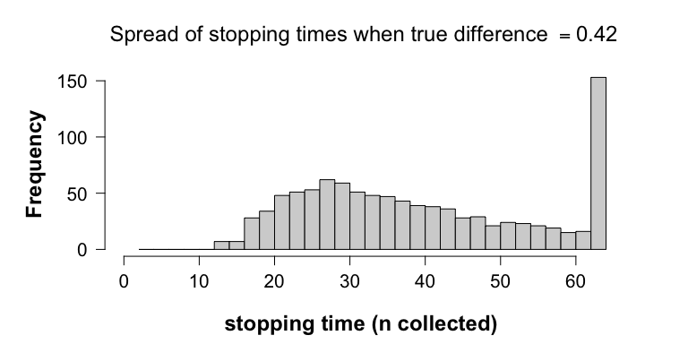

```r
plot(simResultDeltaTrueIsDeltaMin)
```

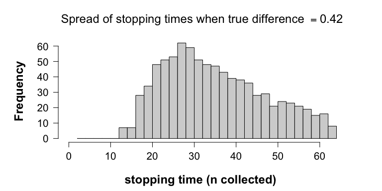

```r
plot(simResultDeltaTrueIsDeltaMin, showOnlyNRejected=TRUE)
```

### Safe tests detect the effect early if it is present: deltaTrue larger than deltaMin

What we believe is clinically minimally relevant might not match reality. One advantage of safe tests is that they perform even better, if the true effect size is larger than the minimal clinical effect size that is used in the planning of the experiment. To see this, we run the following code

```r
# Recall:
# alpha <- 0.05
# beta <- 0.2
# deltaMin <- 9/(sqrt(2)*15)      # = 0.42
deltaTrueLarger <- 0.6

simResultDeltaTrueLargerThanDeltaMin <- simulate(object=designObj,
                                                 nsim=1000L, seed=1,
                                                 deltaTrue=deltaTrueLarger,
                                                 muGlobal=120, sigmaTrue=15)
simResultDeltaTrueLargerThanDeltaMin
```

```
#>
#>    Simulations for Safe Paired Sample T-Test
#>
#> Based on nsim = 1000 and if the true effect size is
#>     deltaTrue = 0.6
#> then the safe test optimised to detect an effect size of at least:
#>     deltaMin = 0.4242641
#> with tolerable type I error rate of
#>     alpha = 0.05 and power: 1-beta = 0.8
#> For experiments with planned sample sizes:
#>     n1Plan = 63 and n2Plan = 63
#>
#> Is estimated to have a null rejection rate of
#>     powerAtNPlan = 0.979
#> at the planned sample sizes.
#>
#> Is estimated to have a null rejection rate of
#>     powerOptioStop = 0.992
#> under optional stopping, and the average stopping time is:
#>     n1Mean = 27.943 and n2Mean = 27.943
```

With a larger true effect size, the power at the sampled sample sizes increases from 79.5% to 97.9%. More importantly, this increase is picked up earlier by the designed safe test, and optional stopping allows us to act on this. Note that the average stopping time is now further decreased, from 39.494 to 27.943. This is apparent from the fact that the histogram of stopping times is now shifted to the left:

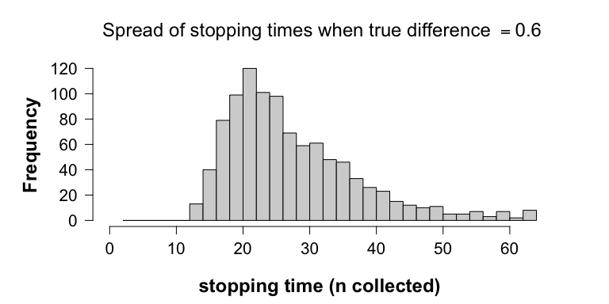

```r
plot(simResultDeltaTrueLargerThanDeltaMin)
```

Hence, this means that if the true effect is larger than what was planned for, the safe test will detect this larger effect earlier on, which results in a further increase of efficiency.

### Optional stopping does not causes safe tests to overreject the null, but is problematic for $p$-values

The previous examples highlight how optional stopping results in an increase in power, i.e., the chance of rejecting the null is increased, when the alternative is true. When the null holds true, however, the rejection rate should be low, at least not larger than the tolerable type I error rate. Here we show that optional stopping results in the type I error rate of the safe test to *not* exceed $\alpha$, whereas early stopping with classical $p$-value tests *does* result in the exceedance of the prescribed $\alpha$-level. In other words, optional stopping with $p$-values leads to an increased risk of falsely claiming that a medicine is effective, while in reality the effect is absent.

For this purpose we run the code

```r
# Recall:
# alpha <- 0.05
# beta <- 0.2
# deltaMin <- 9/(sqrt(2)*15)      # = 0.42

freqDesignObj <- designFreqT(deltaMin=deltaMin, alpha=alpha, beta=beta,
                             alternative="greater", testType="pairedSampleT")

simResultDeltaTrueIsZero <- simulate(object=designObj, nsim=1000L, seed=1,
                                     deltaTrue=0, freqOptioStop=TRUE,
                                     n1PlanFreq=freqDesignObj$n1PlanFreq,
                                     n2PlanFreq=freqDesignObj$n2PlanFreq,
                                     muGlobal=120, sigmaTrue=15)
simResultDeltaTrueIsZero
```

```
#>
#>    Simulations for Safe Paired Sample T-Test
#>
#> Based on nsim = 1000 and if the true effect size is
#>     deltaTrue = 0
#> then the safe test optimised to detect an effect size of at least:
#>     deltaMin = 0.4242641
#> with tolerable type I error rate of
#>     alpha = 0.05 and power: 1-beta = 0.8
#> For experiments with planned sample sizes:
#>     n1Plan = 63 and n2Plan = 63
#>
#> Is estimated to have a null rejection rate of
#>     powerAtNPlan = 0.008
#> at the planned sample sizes.
#> For the p-value test:    freqPowerAtNPlan = 0.051
#>
#> Is estimated to have a null rejection rate of
#>     powerOptioStop = 0.024
#> under optional stopping, and the average stopping time is:
#>     n1Mean = 62.392 and n2Mean = 62.392
#> For the p-value test:    freqPowerOptioStop = 0.233
```

The report shows that the safe test rejects the null with 0.8% chance at the planned sample sizes, and that the classical $p$-value does this with 5.1% chance. Under optional stopping, the safe test led to 24 false null rejecitons out of 1,000 experiments (2.4%), which is still below the tolerable $\alpha=$ 5%-level. On the other hand, optional stopping with $p$-values led to 233 incorrect null rejections out of 1,000 experiments (23.3%). Hence, the simulation study shows that optional stopping causes the $p$-value to overreject the null, when the null holds true.

## 3. Optional Continuation

In the previous section we saw that monitoring the $p$-value and stopping before the planned sample sizes whenever $p < \alpha=0.05$ leads to an increased risk of a false claim (from 5% to 23.3%).

In this section, we first show that optional continuation, that is, extending the experiment beyond the planned sample sizes, also causes the $p$-value to overreject the null. As such, the chance of incorrectly detecting an effect based on $p < \alpha$ will be larger than $\alpha$ whenever (1) funders, reviewers or editors urge the experimenter to collect more data after observing an insignificant $p$-value, because an effect is nonetheless expected, or (2) when other researchers attempt to replicate the original results.

The inability of $p$-values to conserve the $\alpha$-level under optional stopping and optional continuation implies that they only control the risk of an incorrect null rejection, whenever the sample sizes are fixed beforehand and the protocol is followed stringtenly. This requires assuming that no problems occur during the experiment, which might not be realistic in practice, and makes it impossible for practitioners to adapt to new circumstances. In other words, classical $p$-value tests turn the experimental design into a prison for practitioners who care about controlling the type I error rate.

With safe tests one does not need to choose between correct inferences and the ability to adapt to new circumstances, as they were constructed to provide practitioners with additional flexibility in the experimental design without sacrificing the level $\alpha$ type I error control. As safe tests conserve the $\alpha$-level under both optional stopping and continuation, they yield anytime-valid inferences. The robustness of safe tests to optional continuation is illustrated with additional simulations.

### How optional continuation is problematic for $p$-values

Firstly, we show that optional continuation also causes $p$-values to overreject the null. In the following we consider the situation in which we continue studies for which a first batch of data resulted in $p \geq \alpha$. These non-significant experiments are extended with a second batch of data with the same sample sizes as the first batch, that is, n1PlanFreq=36 and n2PlanFreq=36. We see that selectively continuing non-significant experiments causes the collective rate of false null rejections to be larger than $\alpha$.

The following code simulates 1,000 (first batch) experiments under the null, each with the same (frequentist) sample sizes as planned for resulting in 1,000 $p$-values:

```r
dataBatch1 <- generateTTestData(n1Plan=freqDesignObj$n1PlanFreq,
                               n2Plan=freqDesignObj$n2PlanFreq,
                               deltaTrue=0, nsim=1000, paired=TRUE, seed=1,
                               muGlobal=120, sigmaTrue=15)

pValuesBatch1 <- vector("numeric", length=1000)

for (i in seq_along(pValuesBatch1)) {
  pValuesBatch1[i] <- t.test(x=dataBatch1$dataGroup1[i, ],
                             y=dataBatch1$dataGroup2[i, ],
                             alternative="greater", paired=TRUE)$p.value
}
mean(pValuesBatch1 > alpha)
```

```
#> [1] 0.954
```

```r
sum(pValuesBatch1 < alpha)
```

```
#> [1] 46
```

Hence, after a first batch of data, we get 46 incorrect null rejections out of a 1,000 experiments (4.6%).

The following code continues only the non-significant 954 experiments with a second batch of data all also generated under the null, and plots two histograms.

```r
selectivelyContinueDeltaTrueIsZeroWithP <-
  selectivelyContinueTTestCombineData(oldValues=pValuesBatch1,
                                      valuesType="pValues",
                                      alternative="greater",
                                      oldData=dataBatch1,
                                      deltaTrue=0,
                                      n1Extra=freqDesignObj$n1PlanFreq,
                                      n2Extra=freqDesignObj$n2PlanFreq,
                                      alpha=alpha,
                                      seed=2, paired=TRUE,
                                      muGlobal=120, sigmaTrue=15)
```

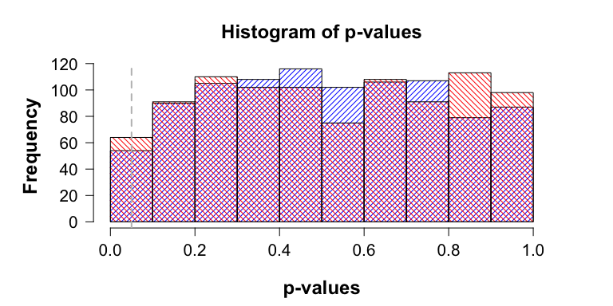

The blue histogram represents the distribution of the 954 non-significant $p$-values calculated over the first batch of data, whereas the red histogram represents the distribution of $p$-values calculated over the two batches of data combined.

The commands

```r
pValuesBatch1To2 <- selectivelyContinueDeltaTrueIsZeroWithP$newValues
sum(pValuesBatch1To2 < alpha)
```

```
#> [1] 28
```

show that by extending the non-significant results of the first batch with a second batch of data, we got another 28 false null rejections. This brings the total number of incorrect null rejections to 74 out of 1,000 experiments, hence, 7.4%, which is above the tolerable $\alpha$-level.

The reason why $p$-values overreject the null under optional stopping and optional continuation is due to $p$-values being uniformly distributed under the null. As such, if the null holds true and the number of samples increases, then the $p$-value meanders between 0 and 1, thus, eventually crossing any fixed $\alpha$-level.

### Two ways to optionally continue studies with safe tests

Safe tests, as we will show below, do conserve the type I error rate under optional continuation. Optional continuation implies gathering more samples than was planned for because, for instance, (1) more funding came available and the experimenter wants to learn more, (2) the evidence looked promising, (3) a reviewer or editor urged the experimenter to collect more data, or (4) other researchers attempt to replicate the first finding.

A natural way to deal with the first three cases is by computing an s-value over the combined data set. This is permitted if the data come from the same population, and if the s-value used is a *test martingale*, which the s-values in this package are.

Replication attempts, however, are typically based on samples from a different population. One way to deal with this is by multiplying the s-value computed from the original study with the s-value computed from the replication attempt. In this situation, the s-value formula for the replication study could also be *redesigned* through the function, for example when more information on nuisance parameters or effect size has become available for designing a more powerful test.

We show that both procedures are safe, that is, they do not lead to the tolerable type I error rate be exceeded, whereas classical $p$-values once again overreject.

### a. Optional continuation by *extending* the experiment does not result in safe tests exceeding the tolerable $\alpha$-level

In this subsection, we show that only continuing studies for which $S \leq 1/ \alpha$ does *not* lead to an overrejection of the null. This is because the sampling distribution of s-values under the null slowly drifts towards smaller values as the number of samples increases.

Again, we consider the situation in which we only continue studies for which the original s-values did not lead to a null rejection. For the first batch of s-values, we use the simulation study ran in the previous section, and we recall that under optional stopping we get

```r
dataBatch1 <- list(dataGroup1=simResultDeltaTrueIsZero$safeSim$dataGroup1,
                   dataGroup2=simResultDeltaTrueIsZero$safeSim$dataGroup2)

sValuesBatch1 <- simResultDeltaTrueIsZero$safeSim$sValues
sum(sValuesBatch1 > 1/alpha)
```

```
#> [1] 24
```

thus, 24 false null rejections out of 1,000 experiments.

The follow-up batches of data will be of the same size as the original, thus, n1Plan=63 and n2Plan=63, and will also be generated under the null. The slow drift to lower s-values is visualised by two histograms. The blue histogram represents the sampling distribution of s-values of the original simulation study that did not resulted in a null rejection. The red histogram represents the sampling distribution of s-values computed over the two batches of data combined. To ease visualisation, we plot the histogram of the log s-values; a negative log s-value implies that the s-value is smaller than one, whereas a positive log s-value corresponds to s-values larger than one. For this we run the following code:

```r
selectivelyContinueDeltaTrueIsZero <-
  selectivelyContinueTTestCombineData(oldValues=sValuesBatch1,
                                      designObj=designObj,
                                      alternative="greater",
                                      oldData=dataBatch1,
                                      deltaTrue=0,
                                      seed=2, paired=TRUE,
                                      muGlobal=120, sigmaTrue=15,
                                      moreMainText="Batch 1-2")
```

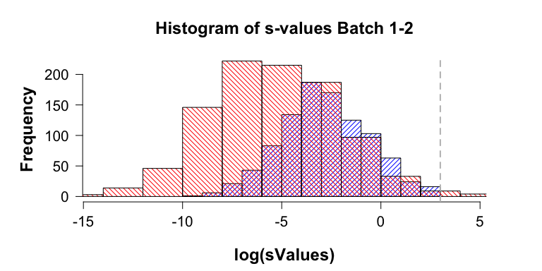

Note that compared to blue histogram, the red histogram is shifted to the left, thus, the sampling distribution of s-values computed over the two batches combined concentrates on smaller values. In particular, most of the mass remains under the threshold value of $1/\alpha$, which is represented by the vertical grey line $\log(1/\alpha) \approx 3.00$. This shift to the left is caused by the increase in sample sizes from n1=n2=63 to n1=n2=126. The commands

```r
sValuesBatch1To2 <- selectivelyContinueDeltaTrueIsZero$newValues
sum(sValuesBatch1To2 > 1/alpha)
```

```
#> [1] 7
```

```r
length(sValuesBatch1To2)
```

```
#> [1] 976
```

show that 7 out of the 976 of the selectively continued experiments (0.7%) now result in a null rejection due to optional continuation. Hence, after the second batch of data the total number of total number of false null rejections is 31 out of a total of a 1,000 original experiment, thus, 3.1%.

One might wonder whether further extending the non-rejected experiment will cause the total false rejection rate go above 5%. The following code suggests that it does not:

```r
for (j in 1:3) {
  oldSValues <- selectivelyContinueDeltaTrueIsZero$newValues
  oldData <- selectivelyContinueDeltaTrueIsZero$combinedData

  selectivelyContinueDeltaTrueIsZero <-
  selectivelyContinueTTestCombineData(oldValues=oldSValues,
                                      designObj=designObj,
                                      alternative="greater",
                                      oldData=oldData,
                                      deltaTrue=0,
                                      seed=2+j, paired=TRUE,
                                      muGlobal=120, sigmaTrue=15,
                                      moreMainText=paste("Batch: 1 to", j+2))
  print(paste("Batch: 1 to", j+2))
  print(paste("Number of rejections:",
              sum(selectivelyContinueDeltaTrueIsZero$newValues > 1/alpha)))
}
```

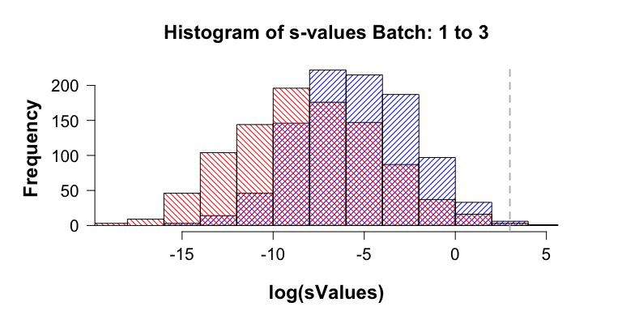

```
#> [1] "Batch: 1 to 3"
#> [1] "Number of rejections: 1"
#> [1] "Batch: 1 to 4"
#> [1] "Number of rejections: 0"
#> Warning in safeTTestStat(t = t, deltaS = designObj[["deltaS"]], n1 = n1, :
#> Overflow: s-value smaller than 0
```

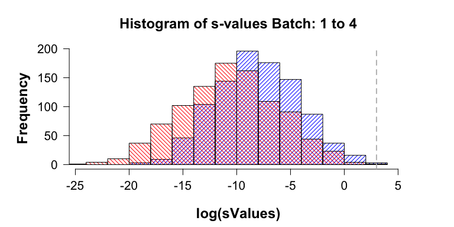

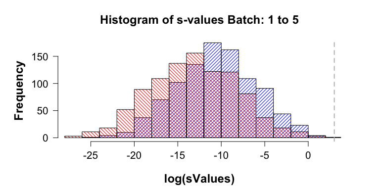

```
#> [1] "Batch: 1 to 5"
#> [1] "Number of rejections: 0"
```

The simulations show that the realised number of false null rejections decreases as the number of replication attempts increases (24, 7, 1, 0, 0, …). Consequently, the collective rate of false null rejections remains well below the tolerable $\alpha$-level. The histograms slowly drifting to the left show that the chance of seeing an s-value larger than $1/\alpha$ decreases under the null as the number of samples increases.

#### When the effect is present optional continuation results in safe tests correctly rejecting the null

The slow drift of the sampling distribution of s-values to smaller values is replaced by a fast drift to large values whenever there is an effect. We again consider the situation in which we continue studies for which the first batch of s-values did not lead to a null rejection. The follow-up batch of data will again be of the same sizes, thus, n1Plan=63 and n2Plan=63, and generated under the assumption that deltaTrue equal deltaMin, as in the first batch.

As a first batch of s-values, we use the simulation study ran in the previous section when deltaTrue equals deltaMin, and we recall that under optional stopping we get

```r
dataBatch1 <- list(
  dataGroup1=simResultDeltaTrueIsDeltaMin$safeSim$dataGroup1,
  dataGroup2=simResultDeltaTrueIsDeltaMin$safeSim$dataGroup2
)

sValuesBatch1 <- simResultDeltaTrueIsDeltaMin$safeSim$sValues
sum(sValuesBatch1 > 1/alpha)
```

```
#> [1] 855
```

855 correct null rejections, since this simulation is based on data generated under alternative with deltaTrue=deltaMin > 0.

The following code selectively continues the 145 experiments which did not lead to a null rejection:

```r
selectivelyContinueDeltaTrueIsDeltaMin <-
  selectivelyContinueTTestCombineData(oldValues=sValuesBatch1,
                                      designObj=designObj,
                                      alternative="greater",
                                      oldData=dataBatch1,
                                      deltaTrue=deltaMin,
                                      seed=2, paired=TRUE, muGlobal=120,
                                      sigmaTrue=15)
```

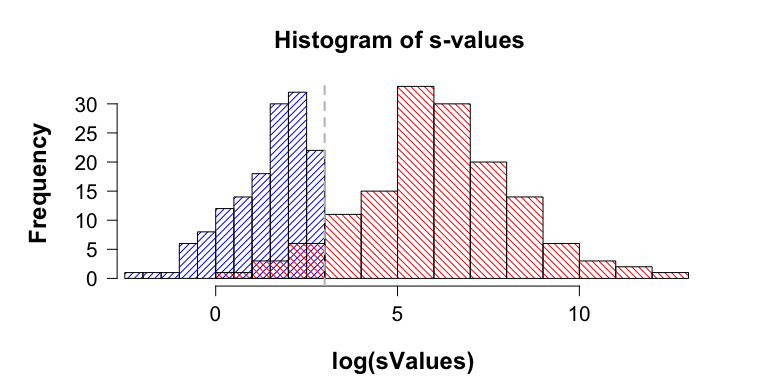

The plot shows that after the second batch of data that the sampling distribution of s-values now concentrates on larger values, as is apparent from the blue histogram shifting to the red histogram on the right. Note that most of the red histogram’s mass is on the right-hand side of the grey vertical line that represents the $\alpha$ threshold (e.g., $\log(1/\alpha) \approx 3$. The continuation of the 145 experiments with $S < 1/\alpha=20$ led to

```r
sValuesBatch1To2 <- selectivelyContinueDeltaTrueIsDeltaMin$newValues
sum(sValuesBatch1To2 > 1/alpha)
```

```
#> [1] 135
```

an additional 135 null rejections (93.1% of 145 experiments). This brings up the total number of null rejections to 990 out of 1,000 experiments. In this case, a null rejection is correct, since the data were generated with a true effect that was equal to deltaMin.

### b. Optional continuation through replication studies

It is not always appropriate to combine data sets, in particular for replication attempts where the original experiment is performed in a different population. In that case, one can still easily do safe inference by multiplying the s-values computed over each data set separately. This procedure also conserves the $\alpha$-level, as we show below.

In all scenarios the simulation results of the optional stopping studies are used as original experiments. The data from these simulated experiments were all generated with a global population mean (e.g., baseline blood pressure) that was set to $\mu_{g}=120$, a population standard deviation of $\sigma=15$, and a deltaTrue, which depending on the absence or presence of the effect was zero, or equal to deltaMin, respectively.

#### Multiplying s-values under the null

As original experiments we take the s-values from the optional stopping simulation study

```r
sValuesOri <- simResultDeltaTrueIsZero$safeSim$sValues
```

The code below multiplies these original s-values with s-values based on replication data, which as in the original studies are generated under the null. Suppose that for the replication attempt we now administer the same drug to a clinical group that has a lower overall baseline blood pressure of $\mu_{g}=90$ mmHg and standard deviation of $\sigma=6$.

```r
# Needs to be larger than 1/designObj$n1Plan to have at least two samples
# in the replication attempt
someConstant <- 1.2

repData <- generateTTestData(n1Plan=ceiling(someConstant*designObj$n1Plan),
                             n2Plan=ceiling(someConstant*designObj$n2Plan),
                             deltaTrue=0, nsim=1000,
                             muGlobal=90, sigmaTrue=6,
                             paired=TRUE, seed=2)

sValuesRep <- vector("numeric", length=1000)

for (i in seq_along(sValuesRep)) {
  sValuesRep[i] <- safeTTest(x=repData$dataGroup1[i, ],
                          y=repData$dataGroup2[i, ],
                          designObj=designObj,
                          alternative="greater", paired=TRUE)$sValue
}
sValuesMultiply <- sValuesOri*sValuesRep
mean(sValuesMultiply > 1/alpha)
```

```
#> [1] 0.003
```

This shows that the type I error (0.3% < $\alpha=5$%) is controlled for, even if the replication attempt is done on a different population. In fact, the $\alpha$-level is controlled for regardless of the values of the nuisance parameters (e.g., $\mu_{g}$ and $\sigma$), or the sample sizes of the replication attempt as long as they are larger than 2 (i.e., “someConstant” larger than 0.0159).

#### Multiplying s-values under the alternative

As original experiments we now take the s-values from the optional stopping simulation study with deltaTrue equal to deltaMin:

```r
sValuesOri <- simResultDeltaTrueIsDeltaMin$safeSim$sValues
```

The code below multiplies these original s-values with s-values based on replication data, which as in the original studies are generated under deltaTrue equal to deltaMin, but with different nuisance parameters, e.g., $\mu_{g}=110$ and $\sigma=50$, thus, much more spread out than in the original studies.

```r
# Needs to be larger than 1/designObj$n1Plan to have at least two samples
# in the replication attempt
someConstant <- 1.2

repData <- generateTTestData(n1Plan=ceiling(someConstant*designObj$n1Plan),
                             n2Plan=ceiling(someConstant*designObj$n2Plan),
                             deltaTrue=deltaMin, nsim=1000,
                             muGlobal=110, sigmaTrue=50,
                             paired=TRUE, seed=2)

sValuesRep <- vector("numeric", length=1000)

for (i in seq_along(sValuesRep)) {
  sValuesRep[i] <- safeTTest(x=repData$dataGroup1[i, ],
                          y=repData$dataGroup2[i, ],
                          designObj=designObj,
                          alternative="greater", paired=TRUE)$sValue
}
sValuesMulti <- sValuesOri*sValuesRep
mean(sValuesMulti > 1/alpha)
```

```
#> [1] 0.988
```

This led to 988 null rejections out of the 1,000 experiments, which is the correct result as the effect is across the original and replication studies.

## Subconclusion

We believe that optional continuation is essential for (scientific) learning, as it allows us to revisit uncertain decisions such as ($p < \alpha$ and $S > 1/\alpha$) either by extending an experiment directly, or via replication studies. Hence, we view learning as an ongoing process, which requires that inference becomes more precise as data accumulate. The inability of $p$-values to conserve the $\alpha$-level under optional continuation, however, is at odds with this view –by gathering more data after an initial look, the inference becomes less precise, as the likelihood of the null being true after observing $p < \alpha$ increases beyond what is tolerable.

Safe tests on the other hand benefit from more data, as the chance of seeing $S > 1/\alpha$ (slowly) decreases when the null is true, whereas it (quickly) increases when the alternative is true, as the number of samples increases.

# Tests of two proportions

## 1. Designing Safe Experiments

The safestats package also contains a safe alternative for tests of two proportions. The standard tests for this setting, which cannot deal with optional stopping, are Fisher’s exact test or the chi-squared test. These tests are applicable to data collected from two groups (indicated with “a” and “b” from here), where each data point is a binary outcome 0 (e.g., deceased) or 1 (e.g., survived). For example, group “a” might refer to the group of patients that are given the placebo, whereas group “b” is given the drug.

### Case (I): Designing experiments with the minimal clinically relevant effect size known

As with the t-test, we might know the minimal clinically relevant effect size upfront for our test of two proportions. For example, we might only be interested in further researching or developing a drug when the difference in the proportion of cured patients in the treatment group compared to the placebo group is at least 0.3. In practice this implies, for example, that when 20% of patients get cured on average in the placebo group, we want the drug to add at least 30% to this average, so in the treated group 50% of patients should be cured. We could design a safe test for this study:

```r
safeDesignProportions <- designSafeTwoProportions(deltaMin=0.3, alpha=0.05,
                                                  beta=0.20, lowN=100,
                                                  numberForSeed = 5227)
```

```
#> Trying n = 100 102 104 106 108 110 112 114 116 118 120 122 124 126 128 130 132 134 136 138 140
#> For all p1, power above desired level. Worst case: 0.81 with data generated from: 0.475 0.175.
```

For detecting this difference with a power of at least 80%, while testing at significance level 0.05, we would need:

```r
safeDesignProportions$n.star
```

```
#> [1] 140
```

patients.

A safe test could now be performed with this design object; for this, some mock data are generated below:

```r
sampleExample <- as.table(matrix(c(10, safeDesignProportions[["na"]]-10, 40,
                                   safeDesignProportions[["nb"]]-40),
                                 byrow=TRUE, nrow=2))
colnames(sampleExample) <- c(0, 1)
sampleExample
```

```
#>    0  1
#> A 10 60
#> B 40 30
```

Performing the safe test:

```r
safeTwoProportionsTest(x = sampleExample, testDesign = safeDesignProportions)
```

```
#>
#>     Safe test for 2x2 contingency tables
#>
#> data:
#>    0  1
#> A 10 60
#> B 40 30
#> The test designed with alpha = 0.05
#> s-value = 13512.96 > 1/alpha = 20 : TRUE
#>
#> Experiments required naPlan = 70 and nbPlan = 70 samples,
#> to guarantee a power of at least 0.8 (beta =0.2),
#> under the alternative hypothesis:
#>        true difference between proportions in group a and b is not equal to 0
#> and deltaMin = 0.3
```

### Case (II): Minimal clinically relevant effect size unknown, but maximum number of samples known.

We might not have enough resources to fund our study to detect the minimal difference of 0.3. For example, we might only have funds to treat 50 patients in each group, so 100 in total. If this is the case, we could, just as with the t-test, inspect the minimal number of patients we need for the experiment to achieve a power of 80% at our significance level per effect size of interest:

```
#> Simulation progress part 1, determining n design:
#> ================================================================================
#> Simulation progress part 2, determining n optional stop:
#> ================================================================================
```

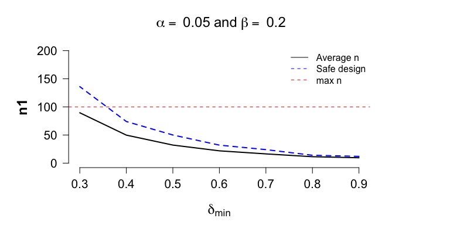

```r
plotResult <- plotSafeTwoProportionsSampleSizeProfile(alpha=0.05,
                                                      beta=0.20,
                                                      highN=200,
                                                      maxN=100,
                                                      numberForSeed=5222)
```

Observe that the smallest absolute difference detectable with our available resources is 0.4; we might have to cancel the study, or try to acquire more research funds, as with our current funds, we can not guarantee a high enough power for detecting the difference between the groups we are interested in. This implies that, when a non-significant result is obtained, we would be unsure whether this was caused by our underpowered study, or because there was really no difference between the groups.

Furthermore, the plot also shows the *expected sample sizes* under optional stopping. The plot function generates experiments based on the minimal difference corresponding to the x-axis and carries out a simulation with *optional stopping*, i.e., experiments were stopped early as soon as $S > 1/\alpha=20$ was observed, and the realised average number of patients was calculated. Observe that the difference between the planned sample size and the sample size under optional stopping is substantial. In the next section, the behaviour of the safe test for two proportions and Fisher’s exact test under optional stopping is studied further.

## 2. Inference with Safe Tests and Optional Stopping

#### True effect size equals minimal clinically relevant effect size

As with the safe t-test, the safe test for two proportions can be used in the optional stopping setting while retaining the type I error guarantee. In the figure below the spread of the stopping times among 1,000 simulated experiments is depicted, if the real effect size equals the minimal clinically relevant effect size as planned:

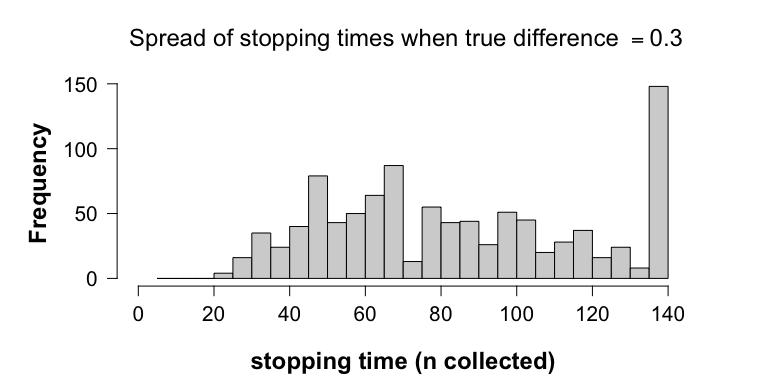

```r
set.seed(5224)

optionalStoppingTrueMeanIsDesign <-
  simulateSpreadSampleSizeTwoProportions(
    safeDesign=safeDesignProportions, M=1000,
    parametersDataGeneratingDistribution=c(0.3, 0.6))

plotHistogramDistributionStoppingTimes(
  optionalStoppingTrueMeanIsDesign,
  nPlan=safeDesignProportions[["n.star"]],
  deltaTrue = 0.3)
```

We designed the safe test such that we had a minimal power of 0.8, would the data truly come from a distribution with an absolute difference of 0.3 between the proportions of cured patients in the groups. Has this power been achieved?

```r
#power achieved:
mean(optionalStoppingTrueMeanIsDesign$rejected == 1)
```

```
#> [1] 0.868
```

#### True effect size larger than the minimal clinically relevant effect size

We have designed the safe test for a minimal clinically relevant effect size, but what would happen if the difference between the groups was even larger in reality, i.e., if the drug had an even bigger effect?

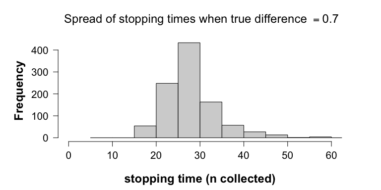

```r
set.seed(5224)

optionalStoppingTrueDifferenceBig <-
  simulateSpreadSampleSizeTwoProportions(
    safeDesign=safeDesignProportions, M=1000,
    parametersDataGeneratingDistribution = c(0.2, 0.9))

plotHistogramDistributionStoppingTimes(
  optionalStoppingTrueDifferenceBig, nPlan=safeDesignProportions[["n.star"]],
  deltaTrue = 0.7)
```

We would stop, on average, even earlier! The power of the experiment also increases:

```r
#power achieved:
mean(optionalStoppingTrueDifferenceBig$rejected == 1)
```

```
#> [1] 1
```

#### Data under the null: True effect size is zero, thus, much smaller than the minimal clinically relevant effect size

We can also illustrate what would happen under optional stopping, when our *null hypothesis* that there is no difference between the effect of the drug and the placebo is true:

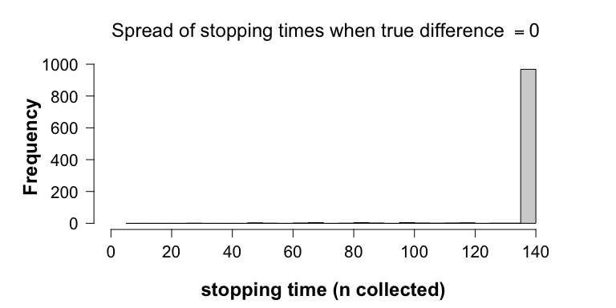

```r
set.seed(5224)

optionalStoppingTrueMeanNull <-
  simulateSpreadSampleSizeTwoProportions(
    safeDesign=safeDesignProportions, M=1000,
    parametersDataGeneratingDistribution = c(0.5, 0.5))

plotHistogramDistributionStoppingTimes(
  optionalStoppingTrueMeanNull,
  nPlan=safeDesignProportions[["n.star"]],
  deltaTrue = 0)
```

The type I error rate has stayed below 0.05:

```r
# The rate of false null rejections remained under alpha=0.05
mean(optionalStoppingTrueMeanNull$rejected == 1)
```

```
#> [1] 0.032
```

#### Classical test “Fisher’s exact test” under the null with optional stopping

Optional stopping, however, causes Fisher’s exact test to overreject the null. When the null is true, the rate of incorrect null rejections exceeds the tolerable $\alpha$-level:

```r
set.seed(5224)

fisher_result <- simulateFisherSpreadSampleSizeOptionalStopping(
  deltaDesign=0.5, alpha=0.05, nDesign=safeDesignProportions$n.star,
  power=0.8, M=100, parametersDataGeneratingDistribution=c(0.5, 0.5))
```

```
#> Starting optional stopping simulations:
#> ================================================================================
```

```r
mean(fisher_result$rejected == 1)
```

```
#> [1] 0.2
```

Thus, 20% which is four times as much as promised.

## 3. Optional Continuation for tests of two proportions

In each of the simulations above, a fraction of the experiments did not lead to the rejection of the null hypothesis. Since safe tests allow for optional continuation, one could decide to plan a replication experiment after such a ‘failed’ first experiment, for example when the s-value looks promisingly high. The resulting s-values from these replication studies could then be multiplied to calculate a final s-value.

We are now going to zoom in on two of the optional stopping simulations we carried out above, where the true difference between the groups equaled our design difference (0.3), and where the true difference equaled 0. In the experiment where the true difference was 0.3, we did not reject the null in 13.2% of the studies. If we now imagine the situation we would encounter in reality, where we would not know that we were really sampling from the alternative hypothesis, how high should s-values then be to support starting a replication study? To give us some handles, we could look at the spread of s-values from studies where the null was not rejected, from our experiments under the null and under the alternative:

```r
notRejectedIndex <- which(optionalStoppingTrueMeanIsDesign$rejected==FALSE)
sValuesNotRejected <- optionalStoppingTrueMeanIsDesign$s_values[notRejectedIndex]
nullNotRejectedIndex <- which(optionalStoppingTrueMeanNull$rejected == FALSE)
sValuesNotRejectedNull <- optionalStoppingTrueMeanNull$s_values[nullNotRejectedIndex]
```

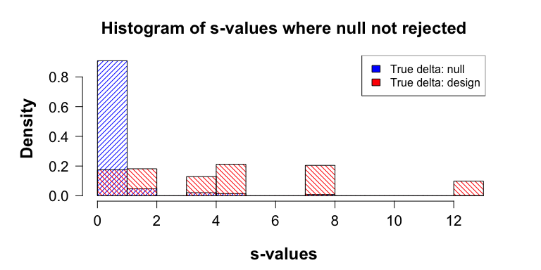

It can be observed that, when the true difference between the groups equals our design difference, the s-values are spread out between 0 and 13. On the other hand, whith our experiment under the null, all s-values were smaller than 8.

Based on this plot we could for example conclude that studies that yielded a final S-value between 10 and 20 look promising; under the null hypothesis, such high S-values were not observed in the spread plot! What would happen if we followed these studies up with a small extra study with 40 participants, and combined the resulting S-values? How many of the initially futile experiments will now lead to rejection of the null hypothesis?

```r
continueIndex <- which(optionalStoppingTrueMeanIsDesign$s_values < 20 &
                         optionalStoppingTrueMeanIsDesign$s_values > 10)

interestingSValues <-
  optionalStoppingTrueMeanIsDesign$s_values[continueIndex]

newSValues <-
  simulateOptionalContinuationTwoProportions(
    interestingSValues, nFollowUp=40,
    parametersDataGeneratingDistribution=c(0.3, 0.6))

mean(newSValues>=20)
```

```
#> [1] 0.5384615
```

What happens when we apply this optional continuation when the data are truly generated under the null hypothesis? (note that we relax our bound of initial ‘interesting’ S-values here to 1, otherwise there would be no S-values to continue with)

```r
continueIndex <- optionalStoppingTrueMeanNull$s_values < 20 &
  optionalStoppingTrueMeanNull$s_values > 1

interestingSValues <-optionalStoppingTrueMeanNull$s_values[continueIndex]

newSValues <-
  simulateOptionalContinuationTwoProportions(
    interestingSValues, nFollowUp=40,
    parametersDataGeneratingDistribution=c(0.5, 0.5))

mean(newSValues>=20)
```

```
#> [1] 0.01136364
```

We still keep our type-I error probability guarantee.

## Short examples of usage of other testing scenarios for two proportions

Some short examples with code snippets for other testing scenarios are illustrated.

#### One-sided testing

Safe tests for two proportions can also be designed for one-sided testing. For the case when one hypothesizes that the population mean of group “a” is higher than the population mean of group “b”:

```r
safeDesignProportionsOneSided <-
  designSafeTwoProportions(deltaMin=0.5, alternative="greater",
                           numberForSeed = 291202)
```

```
#> Trying n = 20 22 24 26 28 30 32 34 36 38 40 42
#> For all p1, power above desired level. Worst case: 0.82 with data generated from: 0.625 0.125.
```

We can now simulate data that fit our hypothesis (more 1s observed in group “a” than in “b”):

```r
sampleExampleGreater <-
  as.table(matrix(c(5, safeDesignProportionsOneSided[["na"]]-5, 19,
                    safeDesignProportionsOneSided[["nb"]]-19),
                  byrow=TRUE, nrow=2))

colnames(sampleExampleGreater) <- c(0,1)
sampleExampleGreater
```

```
#>    0  1
#> A  5 16
#> B 19  2
```

This yields a high s-value:

```r
safeTwoProportionsTest(x=sampleExampleGreater,
                       testDesign=safeDesignProportionsOneSided)
```

```
#>
#>     Safe test for 2x2 contingency tables
#>
#> data:
#>    0  1
#> A  5 16
#> B 19  2
#> The test designed with alpha = 0.05
#> s-value = 3643.678 > 1/alpha = 20 : TRUE
#>
#> Experiments required naPlan = 21 and nbPlan = 21 samples,
#> to guarantee a power of at least 0.8 (beta =0.2),
#> under the alternative hypothesis:
#>        true difference between proportions in group a and b is greater than 0
#> and deltaMin = 0.5
```

But if we now observe the opposite, more 1s in group “b” than in “a”, the s-value will be low;

```r
sampleExampleLesser <-
  as.table(matrix(c(safeDesignProportionsOneSided[["na"]]-5, 5,
                    safeDesignProportionsOneSided[["nb"]]-19, 19),
                  byrow=TRUE, nrow=2))

colnames(sampleExampleGreater) <- colnames(sampleExampleLesser) <- c(0,1)
sampleExampleLesser
```

```
#>    0  1
#> A 16  5
#> B  2 19
```

```r
safeTwoProportionsTest(x=sampleExampleLesser,
                       testDesign=safeDesignProportionsOneSided)
```

```
#>
#>     Safe test for 2x2 contingency tables
#>
#> data:
#>    0  1
#> A 16  5
#> B  2 19
#> The test designed with alpha = 0.05
#> s-value = 0 > 1/alpha = 20 : FALSE
#>
#> Experiments required naPlan = 21 and nbPlan = 21 samples,
#> to guarantee a power of at least 0.8 (beta =0.2),
#> under the alternative hypothesis:
#>        true difference between proportions in group a and b is greater than 0
#> and deltaMin = 0.5
```

#### Unbalanced design: unequal group sizes

When a balanced design is not possible, a safe test of two proportions for unequal sample sizes can be designed as well; the final ratio between the sample sizes one is going to collect has to be known for this.

```r
safeDesignProportionsImbalanced <-
  designSafeTwoProportions(deltaMin=0.3, alpha=0.05, beta=0.20, lowN=120,
                           sampleSizeRatio=2)
```

```
#> Trying n = 120 123 126 129 132 135 138 141 144 147 150 153 156 159 162
#> For all p1, power above desired level. Worst case: 0.81 with data generated from: 0.825 0.525.
```

```r
safeDesignProportionsImbalanced
```

```
#>
#>         Safe Design for Test of Two Proportions
#>
#> Requires an experiment with sample sizes:
#>     naPlan = 54 and nbPlan = 108
#> to find an effect size of at least:
#>     deltaMin = 0.3
#> with:
#>     power = 0.8 (thus, beta = 0.2)
#> under the alternative:
#>     true difference between proportions in group a and b is not equal to 0
#>
#> Based on the decision rule S > 1/alpha:
#>     S > 20
#> which occurs with chance less than:
#>     alpha = 0.05
#> under iid Bernoulli distributed data with the same mean ( proportion) in group a and b.
```